# W10-DWV-Reflection Assignment

Reflection on Labelled Data in R

Alexa Bueno

IBM 6500, Cal Poly Pomona

2026-10-29

# Introduction

## What This Reflection Covers

This deck reflects on the W10 module on wrangling and exploring SPSS data in R. It is organized around the five essay prompts, so each section starts with the prompt and my response follows.

- **Part 1.** What labelled data is, whether my CEP uses it, and which techniques fit my analytics objective
- **Part 2.** The initial data cleaning process from the Covid-19 coffee shop study
- **Part 3.** The further cleaning process from the same study
- **Part 4.** How the two approaches differ and what they did to sample size and response quality

Module materials: the SPSS to R workshop (Center for Customer Insights and Digital Marketing n.d.), plus two cleaning videos (Jung 2025a, 2025b).

# Part 1: Labelled Data and My CEP

## Prompt 1.1: What Is Labelled Data?

**Prompt:** In Step 1, you learned how to read SPSS data into RStudio and conduct EDA and hypothesis testing. What is labelled data? Does your MSDM CEP involve labelled data? Explain why or why not.

Labelled data is data where the values are stored as numeric codes, but each code carries a text label. It usually comes from SPSS (`.sav`), Stata, or SAS files. Survey tools like Qualtrics can export straight to SPSS, which is why it shows up so often in survey research.

. . .

There are two layers of labels:

- A **variable label** holds the full question wording, so a short column name like `Q7` still has meaning.
- **Value labels** connect each code to its answer, like 1 = “Very dissatisfied” and 5 = “Very satisfied”.

In the initial cleaning video, Dr. Jung recommended reading the SPSS file into R instead of a CSV or Excel export, because the SPSS file keeps this metadata.<sup>1</sup> The `haven` package (Wickham, Miller, and Smith n.d.) reads it with `read_sav()` and keeps both layers of labels.

[^1]: The Qualtrics export in that study had 1,185 rows and 209 variables, so a built-in dictionary of labels saves a lot of time going back to the questionnaire.

## What Labelled Data Looks Like in R

Here is a small example I built to see how `haven` handles labels. It mimics one survey question.

```r
q7 <- labelled(
  c(4, 5, 3, 4, 1),
  labels = c("Very dissatisfied" = 1, "Dissatisfied" = 2, "Neutral" = 3,
             "Satisfied" = 4, "Very satisfied" = 5),
  label = "How satisfied were you with your last coffee shop visit?"
)
print_labels(q7)   # shows the code-to-label key
```

```
Labels:
 value             label
     1 Very dissatisfied
     2      Dissatisfied
     3           Neutral
     4         Satisfied
     5    Very satisfied
```

```r
as_factor(q7)      # turns codes into readable categories
```

```
[1] Satisfied         Very satisfied    Neutral           Satisfied
[5] Very dissatisfied
attr(,"label")
[1] How satisfied were you with your last coffee shop visit?
Levels: Very dissatisfied Dissatisfied Neutral Satisfied Very satisfied
```

The codes are what I calculate with (for example, a mean satisfaction score). The labels are what I show a manager in a chart or table.

## Does My CEP Involve Labelled Data?

### No, it does not

My CEP is with Wellness Ranch Therapy (Zhang 2026), and my part is **AO1: SEO performance analysis**. That data comes from Google Search Console and GA4, not from a survey.

### Why not

- Search Console and GA4 export metrics like clicks, impressions, click-through rate (CTR), average position, and sessions.
- They also export text fields like search queries and landing page URLs.
- None of these values are coded answers. A row saying a query got 120 impressions and 4 clicks does not need a codebook to make sense.
- Labelled data comes from survey software, and the current CEP scope does not include a survey.

If our team surveyed Wellness Ranch visitors or donors later, that data would likely be labelled. For now, my data is behavioral and already readable.

## Prompt 1.2: Relevant Techniques for My CEP

**Prompt:** What techniques are relevant for your MSDM CEP? Please elaborate on how these approaches might help you address your AO for CEP.

Even without labelled data, two techniques from the workshop apply directly to AO1: **exploratory data analysis (EDA)** and **hypothesis testing**. My AO1 ties to the CEP research question: *How do implemented website and SEO improvements affect organic search visibility, website traffic, user engagement, and conversion behavior?* Our team is making SEO changes this fall, so my approach is a **before and after comparison**.

- EDA first
- Hypothesis testing
- Why it matters

Before running any test, I need to understand what the data looks like.

- Summarize clicks, impressions, CTR, and average position.
- Plot them over time to spot trends, seasonality, or strange spikes.
- Find which queries and landing pages bring in most organic traffic, since that is where improvements should show up first.
- Catch problems early. A sudden drop could be a tracking issue instead of a real change, and EDA is where I would notice it.

The `count()` and `mutate()` pattern Dr. Jung used constantly for counts and percentages works the same way on query and page data.

Once I have a baseline period and a period after the changes, I can test whether the difference is real or just normal variation.

- Compare CTR for the same pages before and after the updates with a **paired t-test**, since each page is measured twice.
- H0: there is no difference in CTR. H1: CTR changed after the improvements.
- The same setup works for clicks, average position, and engaged sessions from organic search.

```r
# Planned analysis for AO1 (not run yet, data still collecting)
# seo_pages has one row per landing page with CTR before and after the SEO changes
t.test(seo_pages$ctr_after, seo_pages$ctr_before, paired = TRUE)
```

Without a test, it would be easy to point at any increase and call it a success. Testing gives our team and the client stronger evidence for which SEO changes worked and should continue into Spring 2027, and which ones need adjusting.

# Part 2: Initial Data Cleaning

## Prompt 2: The Initial Cleaning Process

**Prompt:** In Step 2, you saw the initial data cleaning process. Describe it and what lessons you got from it.

The video walks through the first round of cleaning for a post-pandemic study on coffee shop behavior (Jung 2025a). The data came from a consumer panel on Prolific, collected in two waves in November and December 2023.

### How the sample was built

- A short screening survey (about 2 minutes) asked which hospitality businesses people had visited: hotels and Airbnb, coffee shops, hair salons, spas, and restaurants.
- Ten establishment types were listed so participants would not know the coffee shop was the target. If they knew, some might claim a visit just to qualify.
- Only adults who visited a coffee shop during the pandemic and stayed at least 15 minutes were invited to the main study. Only about 1 in 4 screened people qualified.

### Why it was split into waves

After wave 1, the team paused to check the participation rate, how much money had been spent, and how much was left. That told them how many more people they could afford to invite in wave 2. About 67% of the data came from wave 1.

Prolific pays participants on behalf of researchers, so every screened person costs money even if they are not eligible.

## Initial Cleaning Steps

1. **Import and tidy the Prolific data.** It was only available as CSV, one file per wave, with the same 19 columns.
2. **Keep only people who were paid.** Approved submissions stayed. A few marked “returned” or “timed out” were reviewed and kept because their responses were usable.
3. **Read the Qualtrics SPSS file** with `read_sav()` and build a data dictionary to see every variable in order.
4. **Join** the Qualtrics data with the Prolific data.
5. **Apply the cleaning criteria section by section:** consent and commitment questions, the repeated coffee shop visit question, and attention or comprehension checks meant to catch bots and inattentive people.
6. **Result:** a working sample of **n = 800**.

One surprise for me: some people said they had visited a coffee shop in the screener and then said they had not in the main study. They had to be removed, which meant the money spent screening them was lost.

## Lessons From the Initial Cleaning

- **Quality control starts in survey design.** The hidden target, the repeated screening question, and the attention checks were all planned ahead. Cleaning was easier because the survey was built to catch bad responses.
- **Use the file that keeps metadata.** SPSS data from Qualtrics carries variable and value labels, so it is a better starting point than CSV or Excel.
- **Cleaning has a real cost.** Every excluded participant was someone the team already paid. Budget and data quality are connected.
- **Use judgment, not only rules.** “Returned” or “timed out” did not automatically mean bad data. The team looked at the actual responses first.
- **Keep the scope manageable.** With 209 variables, Dr. Jung advised narrowing to the variables tied to your objective instead of cleaning everything at once.

# Part 3: Further Data Cleaning

## Prompt 3: The Next Phase of Cleaning

**Prompt:** In Step 3, you saw the next phase of data cleaning. Describe it and what the key takeaways are.

The second video starts with the 800 cases from the first phase (Jung 2025b). Bad respondents had already been screened out, so this should have been clean data. But as Dr. Jung put it, the data was still messy. This phase focuses on the **variables** themselves, plus a few smarter checks on response quality.

### 2. Fix the variables

- Recode Likert items with wrong numbers
- Reverse-code reverse-worded items
- Fix wrong value labels

### 3. Consistency checks

- Compare which COVID measures people said they noticed
- Combine failures with survey duration
- Exclude only clear low-quality cases

## Recoding and Reverse Coding

Two variable problems kept showing up:

- **Wrong codes.** When a survey designer deletes and re-adds answer options in Qualtrics, the codes change behind the scenes. A 7-point scale came out coded 1, 7, 8, 9, 10, 11, 12 instead of 1 through 7, which makes averages meaningless.
- **Reverse-worded items.** “It bothers me when people sneeze without covering their mouth” and “I’m comfortable sharing a water bottle with a friend” point in opposite directions. The second one has to be flipped (8 minus the value) so a high score always means more germ aversion.

Here is a toy version of both fixes, following the pattern from the video:

```r
toy <- tibble(notice_raw   = c(1, 7, 8, 9, 10, 11, 12, 8),
              share_bottle = c(7, 6, 2, 1, 4, 5, 3, 7))

toy <- toy |>
  mutate(notice = case_match(notice_raw,
                             7 ~ 2, 8 ~ 3, 9 ~ 4, 10 ~ 5, 11 ~ 6, 12 ~ 7,
                             .default = notice_raw),
         share_bottle_r = 8 - share_bottle)   # reverse a 1-7 item

# Verify: each old code should match exactly one new code
toy |> count(notice_raw, notice)
```

```
# A tibble: 7 × 3
  notice_raw notice     n
       <dbl>  <dbl> <int>
1          1      1     1
2          7      2     1
3          8      3     2
4          9      4     1
5         10      5     1
6         11      6     1
7         12      7     1
```

The verification step stuck with me. Grouping by the old variable and counting the new one should show a clean one-to-one match. If one old code maps to more than one new code, the recode went wrong.

## Consistency Checks and Final Exclusions

Dr. Jung used a logic check on the question about which COVID measures people noticed at the coffee shop. Mask wearing was the easiest measure to notice. So if someone said they noticed vaccination signs, hand sanitizing, or social distancing **more often** than mask wearing, that was flagged as a failure.

. . .

```r
# Logic from the video (variable names simplified)
covid <- covid |>
  mutate(fail_vax      = if_else(notice_vax      > notice_mask, 1, 0),
         fail_hands    = if_else(notice_hands    > notice_mask, 1, 0),
         fail_distance = if_else(notice_distance > notice_mask, 1, 0),
         n_fail        = fail_vax + fail_hands + fail_distance) |>
  filter(!(n_fail >= 2 & (duration_min < 10 | duration_min > 30)))
```

| Times failed | People |
| --- | --- |
| 0 | 648 |
| 1 | 112 |
| 2 | 31 |

Failing once was treated as fine. Only people who failed **two or more** checks **and** finished in under 10 or over 30 minutes were dropped. That rule removed 9 people.

Dr. Jung also noted that if an item confuses too many people, it is a weak item for screening attention and should not be used to exclude anyone.

## Key Takeaways From the Further Cleaning

- **“Screened” does not mean “clean.”** The 800 cases passed every check in phase 1 and still needed real work before analysis.
- **Always check your codes before calculating anything.** Running `count()` on each variable is what exposed the wrong codes. A mean on a scale coded 1 to 12 would have looked fine and been wrong.
- **Recoding and reverse coding are required. Extra trimming is a judgment call.** Dr. Jung said it was okay not to trim further if it felt too picky, but the recoding had to be done either way.
- **Write small tools for repeated work.** He wrote a simple function for counts and percentages. He also warned that ChatGPT can suggest functions that do not exist, so it only helps if you can check its output.
- **Document every decision.** A reproducible Quarto file shows why each case was kept or dropped.

# Part 4: Comparing the Two Approaches

## Prompt 4: Differences, Sample Size, and Quality

**Prompt:** What are the big differences between the two approaches and the impact on the final sample size and response quality?

Comparison of the two cleaning phases

|  | Initial cleaning (Step 2) | Further cleaning (Step 3) |
| --- | --- | --- |
| Main question | Who belongs in the study? | Are the answers usable and accurate? |
| Level | Respondent level | Variable level, plus a few respondent checks |
| Typical work | Eligibility, consent, payment status, attention checks, joining files | Recoding, reverse coding, fixing labels, logic checks, duration |
| Rules | Mostly set before data collection | Mostly discovered while exploring the data |
| Effect on sample | Large drop | Small drop |
| Effect on quality | Removes people who should not be there | Makes the remaining answers trustworthy for averages and tests |

## Impact on Sample Size

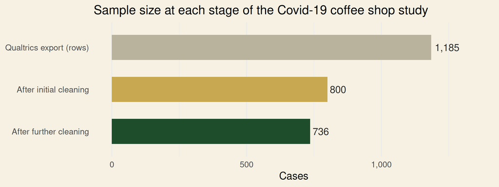

800

Initial cleaning set the working sample. Most of the reduction happened here, and much of it was decided by rules built into the survey design.

736

Further cleaning dropped 64 more cases, about 8%. Dr. Jung called that “not bad.”<sup>1</sup>

[^2]: The video showed the 9 removals from the failure plus duration rule in detail. The rest of the drop from 800 to 736 came from the later cleaning steps he summarized at the end.

## Impact on Response Quality

- The **initial phase** protects the study’s validity by making sure every respondent is real, eligible, and paying attention. Without it, the analysis would include people who never went to a coffee shop.
- The **further phase** protects the measurement. A smaller drop in sample size, but arguably a bigger effect on the results, because miscoded and reverse-worded items would have given wrong averages for every person in the data.
- There is a **trade-off.** Each extra exclusion rule improves quality but costs sample size and the money already spent recruiting. Dr. Jung’s approach was to drop only people who failed multiple checks, not anyone who failed one.

My main takeaway: the first phase decides **who** counts, the second decides **whether their answers mean what we think they mean**. A clean dataset needs both.

# Conclusion

## What I Will Apply to My CEP

Even though my AO1 data is not survey data, the habits from this module carry over.

- **Check uniqueness and duplicates.** In Search Console and GA4 exports, I will make sure pages and queries are not double counted.
- **Look for “impossible” patterns.** Spam or bot traffic in GA4 is like an inattentive respondent. It can inflate sessions and needs to be filtered before I compare before and after periods.
- **Run counts before calculating averages.** The same `count()` and `mutate()` checks will tell me if a metric looks off before I run a t-test.
- **Keep everything reproducible in Quarto,** so our team can see each cleaning decision.

## References

Center for Customer Insights and Digital Marketing. n.d. “Transitioning from Labelled Data to R for Survey Research [Workshop Slides].” Cal Poly Pomona. https://ccidm.github.io/transitioning-spss-to-r/.

Jung, Jae Min. 2025a. “Post-Pandemic Data Initial Cleaning Process [Lecture Video].” Cal Poly Pomona Streaming Video. https://streaming.cpp.edu/media/t/1_4t8fr8h9.

———. 2025b. “Post-Pandemic Research Data Further Cleaning [Lecture Video].” Cal Poly Pomona Streaming Video. https://streaming.cpp.edu/media/t/1_91hyowr0.

Posit. n.d. “Revealjs.” Quarto documentation. https://quarto.org/docs/presentations/revealjs/.

Wickham, Hadley, Evan Miller, and Danny Smith. n.d. “Haven: Import and Export ’SPSS’, ’Stata’ and ’SAS’ Files [R Package].” https://haven.tidyverse.org.

Zhang, Sonya. 2026. “Implementing and Optimizing Digital Marketing for Wellness Ranch Therapy [MSDM CEP Project Proposal].” Cal Poly Pomona, MSDM Culminating Experience Project.

# Appendix

## Links

- GitHub repository: https://github.com/Buenoalexa11/IBM6500
- This .qmd file on GitHub: https://github.com/Buenoalexa11/IBM6500/blob/main/W10-DWV-Reflection-Assignment.qmd
- Rendered slides (GitHub Pages): https://buenoalexa11.github.io/IBM6500/W10-DWV-Reflection-Assignment.html

Built with Quarto Revealjs (Posit n.d.), using the serif theme customized through Sass variables (custom.scss) and extra CSS (styles.css).